## Day 2: Data visualization

### In-class worksheet, solutions

**June 1st, 2022**

## 1. Plotting x-y relationships

### 1.1 Correlations

We will work with the `iris` data set available in R. This data set gives the measurements in centimeters of the variables sepal length, sepal width, petal length and petal width for 50 flowers from each of 3 species of iris. The species are *Iris setosa*, *Iris versicolor*, and *Iris virginica*:

```r
# view the first several rows of the iris data set
head(iris)
```

```
##   Sepal.Length Sepal.Width Petal.Length Petal.Width Species
## 1          5.1         3.5          1.4         0.2  setosa
## 2          4.9         3.0          1.4         0.2  setosa
## 3          4.7         3.2          1.3         0.2  setosa
## 4          4.6         3.1          1.5         0.2  setosa
## 5          5.0         3.6          1.4         0.2  setosa
## 6          5.4         3.9          1.7         0.4  setosa
```

1. Using ggplot, make a scatter plot of petal length vs. sepal length for the three species; the function you need for this is `geom_point()` and you will need to specify `color = Species` inside of `aes()`.

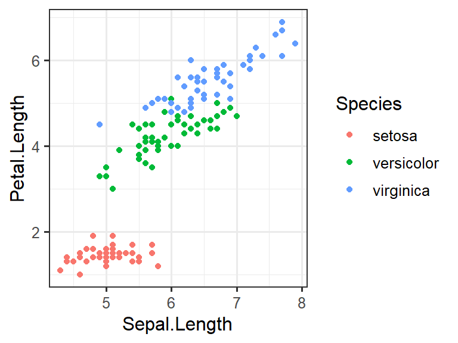

```r
# plot petal length vs sepal length, colored by species
ggplot(iris, aes(x = Sepal.Length, y = Petal.Length, color = Species)) +
  geom_point()
```

2. Do the same plot but facet by `Species` using `facet_wrap()`.

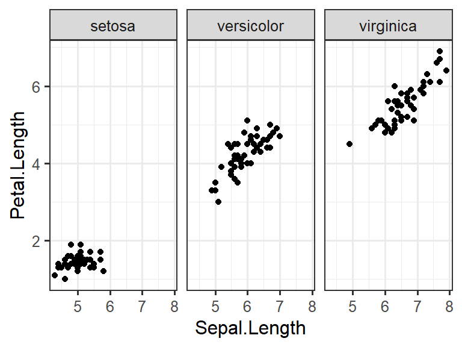

```r
# plot petal length vs sepal length, faceted by species
ggplot(iris, aes(x = Sepal.Length, y = Petal.Length)) +
  geom_point() +
  facet_wrap(~Species)
```

### 1.2 Time series

The `omp` data set contains a subset of DNA microarray data measuring the differential expression of *E. coli* outer membrane proteins (omp) in nutrient-limited chemostatic cultures. In this particular experiment, the medium is glucose-limited. The `gene` column denotes one 8 genes that code for outer membrane proteins, `time_min` denotes the time point sampled in minutes, and `au` denotes the change in gene expression detected by the microarray chip (arbitrary units of fluorescence intensity).

```r
# download the `omp` data set
omp <- read_csv("https://rachaelcox.github.io/classes/datasets/ecoli_omp_expression.csv")
head(omp)
```

```
## # A tibble: 6 x 3
##   gene  time_min    au
##   <chr>    <dbl> <dbl>
## 1 ompA         5 -0.32
## 2 ompA        15  0.46
## 3 ompA        30  0.18
## 4 ompA        60 -0.23
## 5 ompC         5 -0.48
## 6 ompC        15 -0.56
```

1. Plot the expression of each gene over time using `geom_line()`, coloring each line by gene. Notice anything off about this plot?

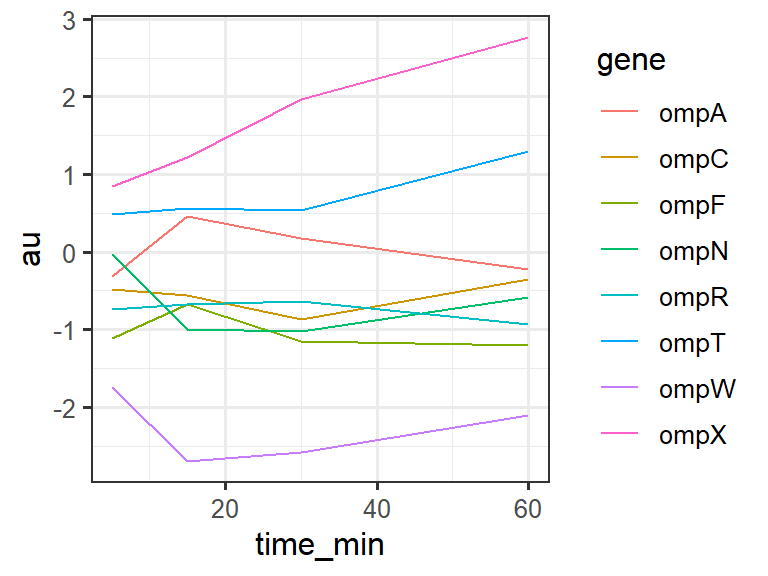

```r
# plot the expression of each gene over time
ggplot(omp, aes(x = time_min, y = au, color = gene)) +
  geom_line()
```

2. Make the same plot but make the size of the lines thicker by specifying the `size` argument inside of `geom_line()`.
3. Use `scale_color_colorblind()` to convert the legend colors to a colorblind-friendly palette.
4. Use `xlab()` and `ylab` to give the figure pretty labels.

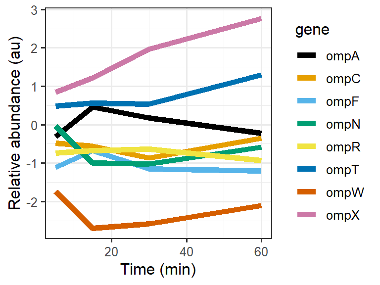

```r
# plot the expression of each gene over time & make it pretty
ggplot(omp, aes(x = time_min, y = au, color = gene)) +
  geom_line(size = 2) +
  scale_color_colorblind() +
  xlab("Time (min)") +
  ylab("Relative abundance (au)")
```

## 2. Plotting amounts

### 2.1 Bar plots

The `bacteria` data set contains data from tests of the presence of the bacterium *H. influenzae* in children with otitis media in the Northern Territory of Australia. We are interested in two columns of this data set: `presence` reports the presence (y) or absence (n) of the bacterium, `treatment` reports the treatment, which was placebo, drug, or drug+ (drug plus high adherence).

```r
# download the `bacteria` data set
bacteria <- read_csv("https://rachaelcox.github.io/classes/datasets/bacteria.csv")
head(bacteria)
```

```
## # A tibble: 6 x 6
##   presence ap    hilo   week ID    treatment
##   <chr>    <chr> <chr> <dbl> <chr> <chr>
## 1 y        p     hi        0 X01   placebo
## 2 y        p     hi        2 X01   placebo
## 3 y        p     hi        4 X01   placebo
## 4 y        p     hi       11 X01   placebo
## 5 y        a     hi        0 X02   drug+
## 6 y        a     hi        2 X02   drug+
```

1. Using `geom_bar()`, make a bar plot with the `treatment` column on the x-axis, assigning the `presence` column to the `fill` argument to visualize the number of patients with and without bacteria for each type of treatment.

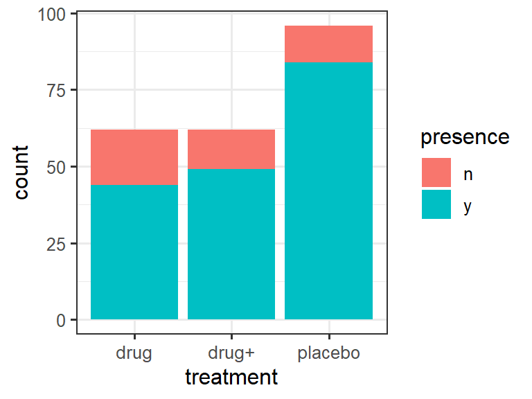

```r
ggplot(bacteria, aes(x = treatment, fill = presence)) +
  geom_bar()
```

Notice that, by default, `geom_bar()` stacks the counts for each class of `presence` on top of each other. Generally, this isn't the clearest way to visualize this type of data. Now:

2. Modify the plot so that bars indicating the patients with or without the bacterium are shown side-by-side. Hint: This requires the argument `position='dodge'` in `geom_bar()`.
3. Use `scale_fill_brewer()` to change the plot colors.

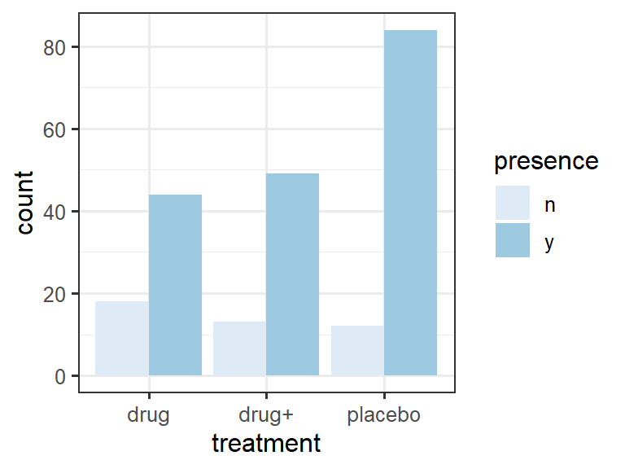

```r
ggplot(bacteria, aes(x = treatment, fill = presence)) +
  geom_bar(position = 'dodge') +
  scale_fill_brewer()
```

4. Modify the plot so that bars represent the relative number of cases with or without the bacterium. What is the appropriate `position` option in `geom_bar()` to achieve this effect? Use `?geom_bar` to find out.
5. Apply an alternative color palette for `scale_fill_brewer()` to use by specifying the `type` and `palette` arguments (see `?scale_fill_brewer` for details).

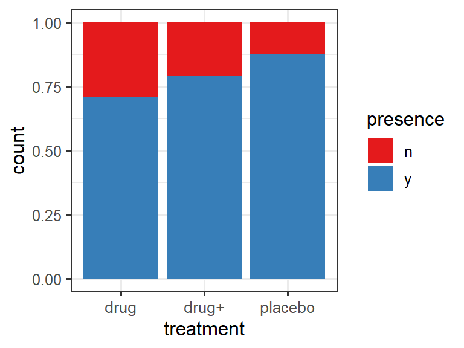

```r
ggplot(bacteria, aes(x = treatment, fill = presence)) +
  geom_bar(position = 'fill') +
  scale_fill_brewer(type = 'qual', palette = 'Set1')
```

### 2.2 Heat maps

```r
# download the dandelion differential expression data set
dandelion <- read_csv("https://rachaelcox.github.io/classes/datasets/dandelion_diffexp_tidy.csv")
head(dandelion)
```

```
## # A tibble: 6 x 8
##   transcript_dand~ baseMean z_score loci_arabidopsis protein_annotat~
##   <chr>               <dbl>   <dbl> <chr>            <chr>
## 1 DN42754_c0_g1_i1     167.    1.28 AT5G67060        Transcription f~
## 2 DN42754_c0_g1_i1     167.    1.28 AT5G67060        Transcription f~
## 3 DN42754_c0_g1_i1     167.    1.28 AT5G67060        Transcription f~
## 4 DN42754_c0_g1_i1     167.    1.28 AT5G67060        Transcription f~
## 5 DN42754_c0_g1_i1     167.    1.28 AT5G67060        Transcription f~
## 6 DN42754_c0_g1_i1     167.    1.28 AT5G67060        Transcription f~
## # ... with 3 more variables: gene_names_primary <chr>, condition <chr>,
## #   log2_foldchange <dbl>
```

1. Plot a heat map using `geom_tile` where each condition is on the x-axis and each gene (either `transcript_dandelion` or `loci_arabidopsis`) is on the y-axis.
2. Fill the color of the heat map using the `log2_foldchange` column. Use `scale_fill_distiller()` to specify a continuous **diverging** color palette.

*(Note that I have told R Markdown to make a larger figure, by starting the code block with* `{r fig.height=6, fig.width=10}` *instead of* `{r}`*, because the default figure size is too narrow to show the resulting axes and map.)*

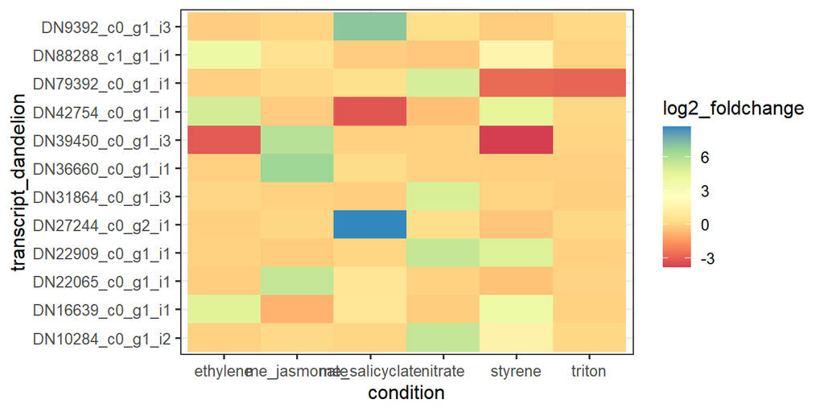

```r
ggplot(dandelion, aes(x = condition, y = transcript_dandelion, fill = log2_foldchange)) +
  geom_tile() +
  scale_fill_distiller(type = 'div',
                       palette = 'Spectral',
                       guide = 'colourbar',
                       direction = 1)
```

3. Make the same plot again, but rotate the text on the x-axis so they aren't mashing into each other.
4. Apply a different color palette this time. You can use a different palette within `scale_fill_distiller()` (see `?scale_fill_distiller`) or you can use a different continuous color function, such as `scale_fill_viridis_c()` or `scale_fill_gradient()`.

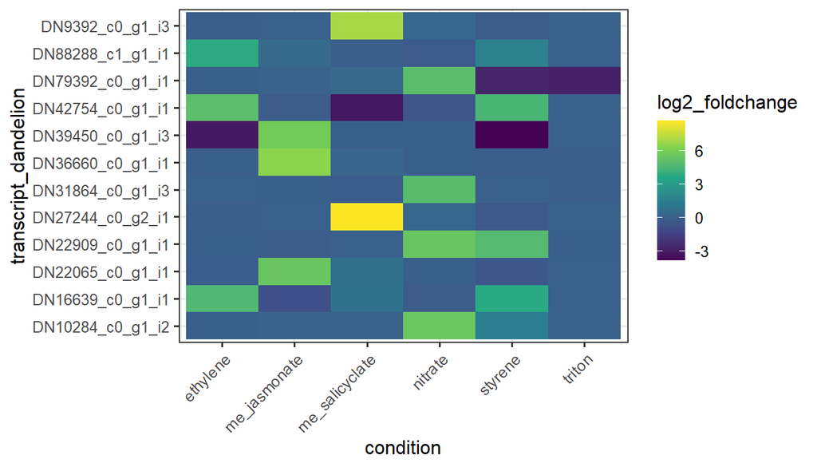

```r
ggplot(dandelion, aes(x = condition, y = transcript_dandelion, fill = log2_foldchange)) +
  geom_tile() +
  scale_fill_viridis_c() +
  theme(axis.text.x = element_text(angle = 45, vjust = 1, hjust = 1)) +
  guides(title = 'log2(fc)')
```

## 3. Plotting distributions

### 3.1 Boxplots, violin plots

1. Using the `biopsy` data set, make boxplots of `clump_thickness` for each type of `outcome`. The geom you need to use is `geom_boxplot()`.

```r
# download the biopsy data set
biopsy <- read_csv("https://rachaelcox.github.io/classes/datasets/biopsy.csv")
head(biopsy)
```

```
## # A tibble: 6 x 10
##   clump_thickness uniform_cell_si~ uniform_cell_sh~ marg_adhesion
##             <dbl>            <dbl>            <dbl>         <dbl>
## 1               5                1                1             1
## 2               5                4                4             5
## 3               3                1                1             1
## 4               6                8                8             1
## 5               4                1                1             3
## 6               8               10               10             8
## # ... with 6 more variables: epithelial_cell_size <dbl>, bare_nuclei <dbl>,
## #   bland_chromatin <dbl>, normal_nucleoli <dbl>, mitoses <dbl>, outcome <chr>
```

```r
summary(biopsy)
```

```
##  clump_thickness  uniform_cell_size uniform_cell_shape marg_adhesion
##  Min.   : 1.000   Min.   : 1.000    Min.   : 1.000     Min.   : 1.00
##  1st Qu.: 2.000   1st Qu.: 1.000    1st Qu.: 1.000     1st Qu.: 1.00
##  Median : 4.000   Median : 1.000    Median : 1.000     Median : 1.00
##  Mean   : 4.442   Mean   : 3.151    Mean   : 3.215     Mean   : 2.83
##  3rd Qu.: 6.000   3rd Qu.: 5.000    3rd Qu.: 5.000     3rd Qu.: 4.00
##  Max.   :10.000   Max.   :10.000    Max.   :10.000     Max.   :10.00
##  epithelial_cell_size  bare_nuclei     bland_chromatin  normal_nucleoli
##  Min.   : 1.000       Min.   : 1.000   Min.   : 1.000   Min.   : 1.00
##  1st Qu.: 2.000       1st Qu.: 1.000   1st Qu.: 2.000   1st Qu.: 1.00
##  Median : 2.000       Median : 1.000   Median : 3.000   Median : 1.00
##  Mean   : 3.234       Mean   : 3.545   Mean   : 3.445   Mean   : 2.87
##  3rd Qu.: 4.000       3rd Qu.: 6.000   3rd Qu.: 5.000   3rd Qu.: 4.00
##  Max.   :10.000       Max.   :10.000   Max.   :10.000   Max.   :10.00
##     mitoses         outcome
##  Min.   : 1.000   Length:683
##  1st Qu.: 1.000   Class :character
##  Median : 1.000   Mode  :character
##  Mean   : 1.603
##  3rd Qu.: 1.000
##  Max.   :10.000
```

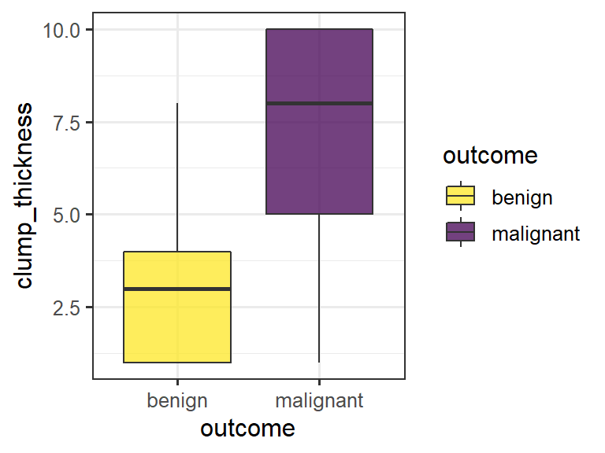

```r
ggplot(biopsy, aes(y = clump_thickness, x = outcome, fill = outcome)) +
  geom_boxplot() +
  scale_fill_viridis_d(direction = -1, alpha = 0.75)
```

2. Make the same plot again, instead using `geom_violin()`. What do you notice?

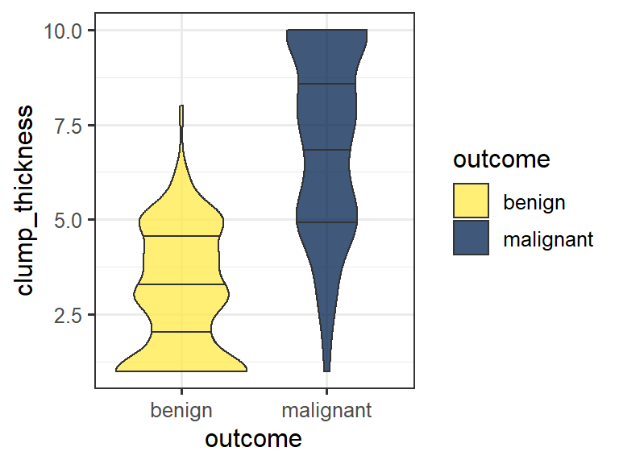

```r
ggplot(biopsy, aes(y = clump_thickness, x = outcome, fill = outcome)) +
  geom_violin(draw_quantiles = c(0.25, 0.5, 0.75)) +
  scale_fill_viridis_d(direction = -1, alpha = 0.75, option = "E")
```

3. Add a layer to your code that creates side-by-side plots of `clump_thickness` distribution for each value of `mitoses` using the `facet_wrap()` function.
4. Try this with and without specifying the `ncol = 3` argument inside of the `facet_wrap()` function.

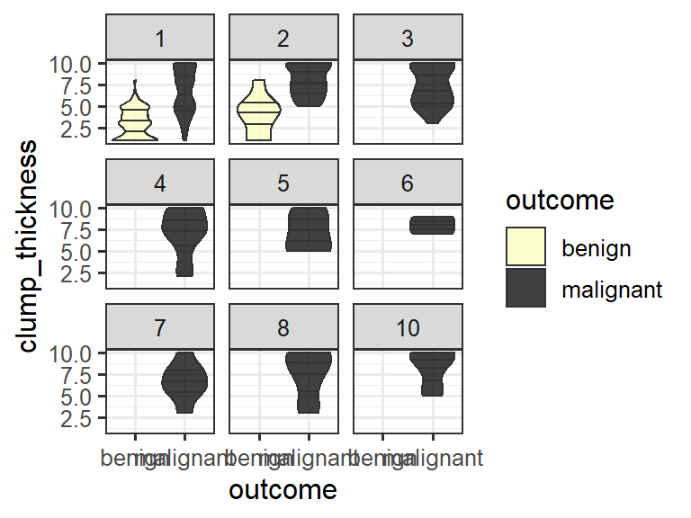

```r
ggplot(biopsy, aes(y = clump_thickness, x = outcome, fill = outcome)) +
  geom_violin(draw_quantiles = c(0.25, 0.5, 0.75)) +
  scale_fill_viridis_d(direction = -1, alpha = 0.75, option = "A") +
  facet_wrap(~mitoses, ncol = 3)
```

### 3.2 Histograms, density plots

1. Make a histogram plot of sepal lengths in the `iris` data set, using the default histogram settings. Use `geom_histogram()`.
2. Make two more such plots, with different bin widths. You can change the bin width by specifying the argument `binwidth =` or `bins =`. See `?geom_histogram` for more information.

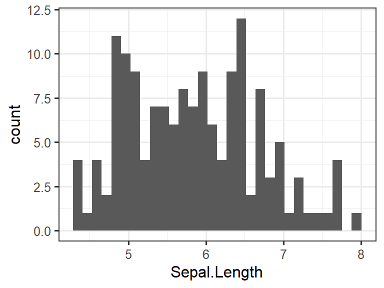

```r
# default settings
ggplot(iris, aes(x = Sepal.Length)) +
  geom_histogram()
```

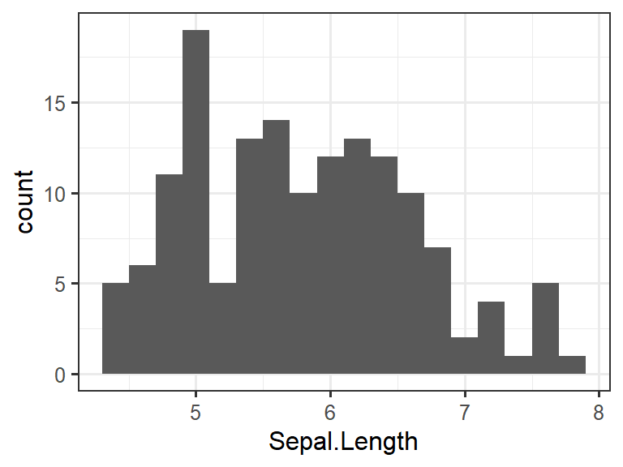

```r
# wider bins
ggplot(iris, aes(x = Sepal.Length)) +
  geom_histogram(binwidth = 0.2)
```

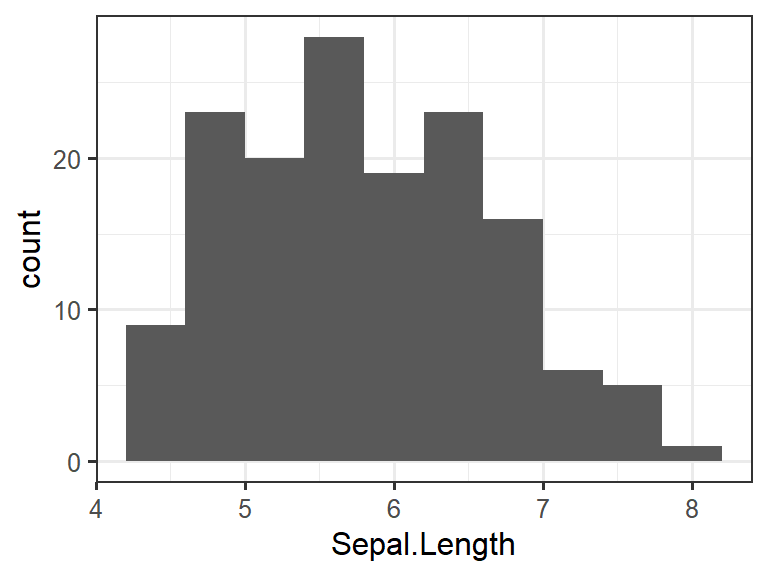

```r
# even wider bins
ggplot(iris, aes(x = Sepal.Length)) +
  geom_histogram(binwidth = 0.4)
```

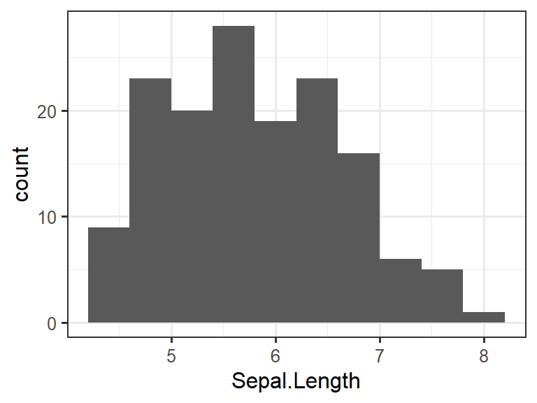

```r
# divide all observations by a set # of bins
ggplot(iris, aes(x = Sepal.Length)) +
  geom_histogram(bins = 10)
```

3. Instead of `geom_histogram()`, now use `geom_density()` and fill the area under the curves by species identity.

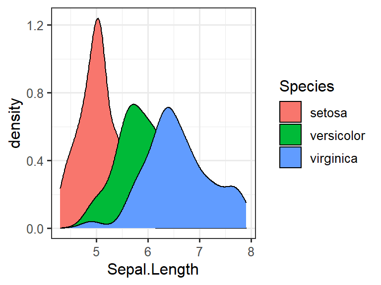

```r
ggplot(iris, aes(x = Sepal.Length, fill = Species)) +
  geom_density()
```

4. Make the areas under the curve partially transparent using the `alpha` argument inside of `geom_density()`, so the overlap of the various distributions becomes clearly visible.

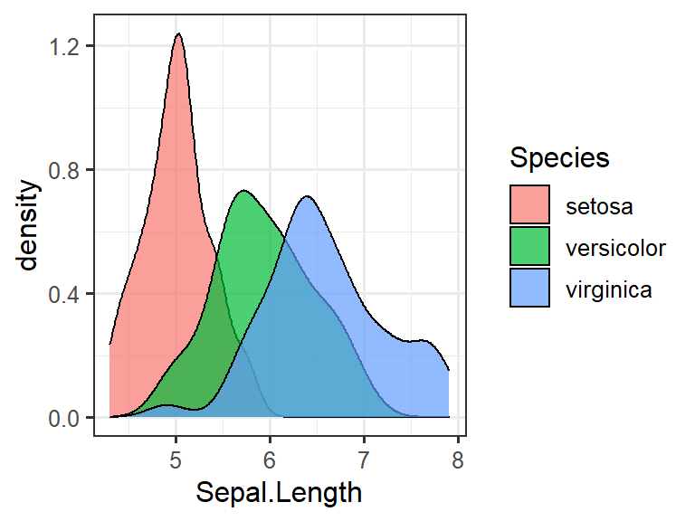

```r
ggplot(iris, aes(x = Sepal.Length, fill = Species)) +
  geom_density(alpha = 0.7)
```

## 4. Layering geoms

**Bonus challenge:** For the `iris` data set, make a plot of the 2d distribution of petal length vs. sepal length, by making an x-y plot that shows the individual data points as well as contour lines indicating the density of points in a given spatial region.

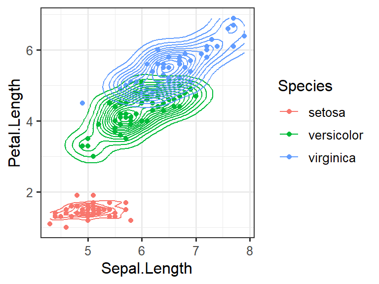

```r
ggplot(iris, aes(x = Sepal.Length, y = Petal.Length, color = Species)) +
  geom_point() +
  geom_density2d()
```

Now instead of contour lines, add a fitted straight black line (not a curve, and no confidence band!) to each group of points. You'll need to check `?geom_smooth` to see which arguments you'll need to specify.

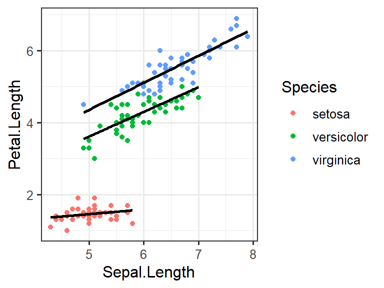

```r
ggplot(iris, aes(x = Sepal.Length, y = Petal.Length, color = Species)) +
  geom_point() +
  geom_smooth(
    aes(group = Species),  # make a line for each species
    method = lm,  # fit a linear model
    color = 'black',
    se = FALSE)  # no confidence interval
```

In this last example, because we are manually overriding the color of the lines, we need to set the group aesthetic to tell ggplot2 to draw a separate line for each species.